# PPC Model

```r
##################################################
## Project: Dairy Spoilage Model
## Script purpose: Validation of the 10k simulations
##################################################
#Edited by SL on 07-14-20
##################################################
```

## 1. Set-up environment

```r
library(splitstackshape)
library(dplyr)
library(ggplot2)
library(readr)
library(MASS)
library(EnvStats)
library(lhs)
```

## 3. Load simulation data

```r
load("Z:/sl2763_Samantha Lau/Projects/2019 FFAR project/Data prep for validation/Model/10ksimulations/Data_10kiterations_truncated_VALIDATION6C.RData")
```

# Data Analysis —-

- Calculate the mean count by day

```r
data %>%
  group_by(day) %>%
  summarise(Mean = mean(count, na.rm=TRUE), SD = sd(count,na.rm=TRUE))-> mean_by_day
```

- Plotting actual counts from day 7, 10, etc from VSL data
  - The actual counts came from VSL data and is in a separate CSV file that gets called in
  - Use this to create histograms to see what VSL data looks like

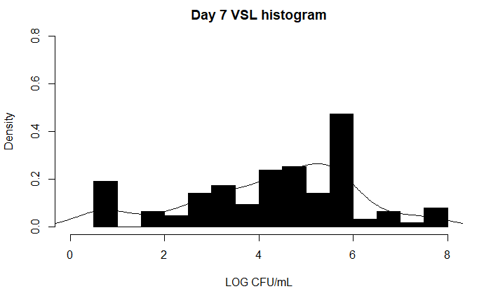

```r
#VSL Data for day 7 and day 10
day7andday10<-read.csv("Log_microbial_count__VSL2018onwardsONLY_validation_MCinput_032520.csv")

#create a histogram/distribution just for the VSL data
logday7<-day7andday10$LOG.D7
newlogday7<-as.numeric(logday7) #use the log day 7 column from VSL data
logday10<-day7andday10$LOG.D10
newlogday10<-as.numeric(logday10) #use the log day 10 column from VSL data

#histogram with proportions for day 7
hist(newlogday7, 10, col="black", main="Day 7 VSL histogram",
     xlab="LOG CFU/mL", xlim=c(0,8), ylim = c(0,0.8), freq = FALSE)
lines(density(na.omit(newlogday7)))
```

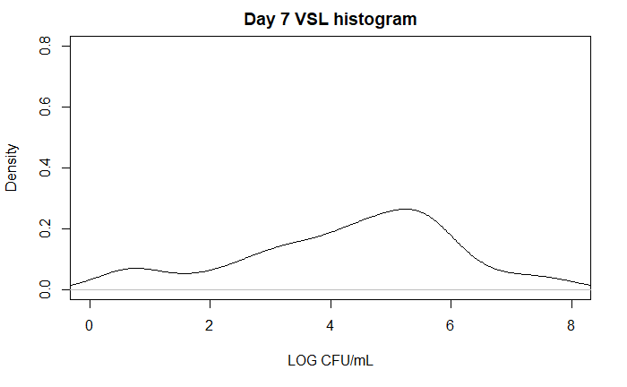

```r
# plot density plot for day 7
plot(density(na.omit(newlogday7)), main="Day 7 VSL histogram",
     xlab="LOG CFU/mL", xlim=c(0,8), ylim=c(0,0.8))
```

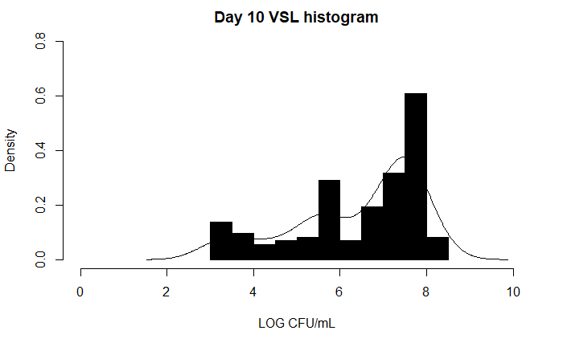

```r
#histogram with proportions for day 10
hist(newlogday10, 10, col="black", main="Day 10 VSL histogram",
     xlab="LOG CFU/mL", xlim=c(0,10), ylim = c(0,0.8), freq = FALSE)
lines(density(na.omit(newlogday10)))
```

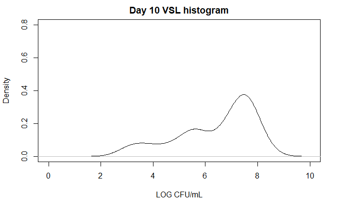

```r
# plot density plot for day 10
plot(density(na.omit(newlogday10)), main="Day 10 VSL histogram",
     xlab="LOG CFU/mL", xlim=c(0,10), ylim=c(0,0.8))
```

```r
shapiro.test(newlogday7)
```

```
    Shapiro-Wilk normality test

data:  newlogday7
W = 0.94053, p-value = 2.811e-05
```

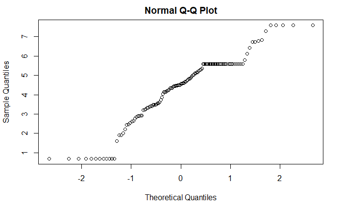

```r
qqnorm(newlogday7)
```

```r
shapiro.test(newlogday10)
```

```
    Shapiro-Wilk normality test

data:  newlogday10
W = 0.88078, p-value = 1.98e-09
```

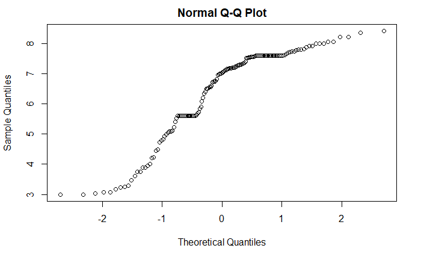

```r
qqnorm(newlogday10)
```

- Simulating data for day 7

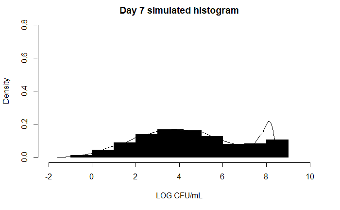

```r
#created a new table data2 just because I don't want to mess with original data
data2<-data

#Make a df only including day and count
data2_counts <- data2[c(4,5)]

#Make df of day 7 only
#Note: You want to change this to day==3 when the initial mean and SD is set using the day 7 data instead of initial
#should this be 6 since day initial is day 1????? or 7
day7counts<- data2_counts[data2_counts$day=="7",]

#only using the count data
day7counts_sim<-day7counts$count

#making a numeric factor
day7counts_sim<-as.numeric(day7counts_sim)

#histogram with simulated day 7
hist(day7counts_sim, 10, col="black", main="Day 7 simulated histogram",
     xlab="LOG CFU/mL", xlim=c(-2,10), ylim = c(0,0.8), freq = FALSE)
lines(density(na.omit(day7counts_sim)))
```

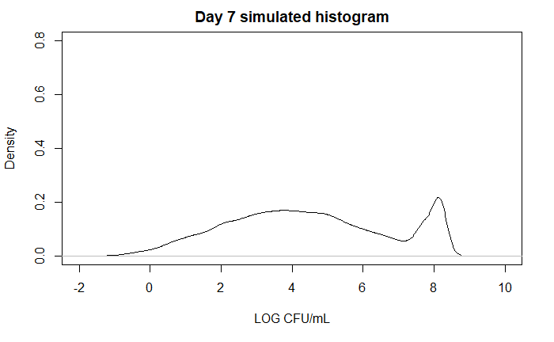

```r
#density plot with day 7 simulated
plot(density(na.omit(day7counts_sim)), main="Day 7 simulated histogram",
     xlab="LOG CFU/mL", xlim=c(-2,10), ylim=c(0,0.8))
```

- Comparing simulated and VSL data for day 7

```r
#create a histogram with both the simulated and the VSL data
plot(density(na.omit(day7counts_sim)), main="Day 7 simulated vs VSL",
     xlab="LOG CFU/mL", xlim=c(-4,10), ylim=c(0,0.8))
lines(density(na.omit(newlogday7)), col="blue")
```

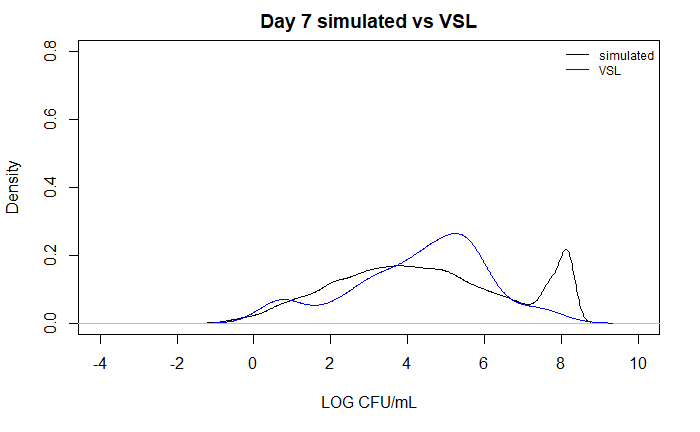

```r
legend('topright',  legend = c("simulated", "VSL"),
       lty=1, col=c('black', 'blue'), bty='n', cex=.75)
```

```r
#shapiro.test(day7counts_sim)
#qqnorm(day7counts_sim)

wilcox.test(newlogday7, day7counts_sim, paired = FALSE)
```

```
    Wilcoxon rank sum test with continuity correction

data:  newlogday7 and day7counts_sim
W = 6269207, p-value = 0.804
alternative hypothesis: true location shift is not equal to 0
```

```r
p=ecdf(day7counts_sim)
p2=ecdf(newlogday7)
plot(p, verticals = TRUE, do.points=FALSE,  xlab="LOG10 CFU/mL", main="Day 7 simulated vs VSL", ylab = "Density", xlim=c(-4,10))
plot(p2, verticals = TRUE, do.points=FALSE, add=TRUE, col="blue")
```

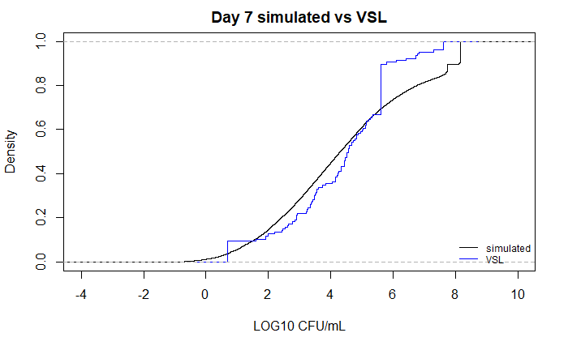

```r
legend('bottomright',  legend = c("simulated", "VSL"),
       lty=1, col=c('black', 'blue'), bty='n', cex=.75)
```

```r
mean(as.numeric(na.omit(day7counts_sim)))
```

```
[1] 4.473049
```

```r
mean(as.numeric(na.omit(newlogday7)))
```

```
[1] 4.302047
```

- Running Kolmogorov-Smirnov test for day 7
  - Purpose: Want to compare the distributions of the VSL versus simulated

```r
#perform Kolmogorov-Smirnov test
ks.test(day7counts_sim, newlogday7, alternative = c("two.sided"), exact = NULL)
```

```
p-value will be approximate in the presence of ties
```

```
    Two-sample Kolmogorov-Smirnov test

data:  day7counts_sim and newlogday7
D = 0.20445, p-value = 4.966e-05
alternative hypothesis: two-sided
```

```r
#calculating critical value
x <- day7counts_sim[!is.na(day7counts_sim)]
n <- length(x)
  y <- newlogday7[!is.na(newlogday7)]
  n.y <- length(y)

#5%level significance
a=1.35810
day7critvalue5<-1.35810*((n+n.y)/(n*n.y))^0.5
day7critvalue5
```

```
[1] 0.1205884
```

```r
alternative <- "two.sided"
x <- day7counts_sim[!is.na(day7counts_sim)]
n <- length(x)
  y <- newlogday7[!is.na(newlogday7)]
  n.x <- as.double(n)
  n.y <- length(y)
  w <- c(x, y)
  z <- cumsum(ifelse(order(w) <= n.x, 1/n.x, -1/n.y))
  z <- z[c(which(diff(sort(w)) != 0), n.x + n.y)] #exclude ties
  STATISTIC <- switch(alternative, two.sided = max(abs(z)),
                      greater = max(z), less = -min(z))
  STATISTIC
```

```
[1] 0.2044478
```

- Simulating data for day 10

```r
#Make df of day 10 only
#Note: change this to day==4 when the initial mean and SD is set using the day 7 data instead of initial
day10counts<- data2_counts[data2_counts$day=="10",]

#only using the count data
day10counts_sim<-day10counts$count

#making a numeric factor
day10counts_sim<-as.numeric(day10counts_sim)

#day10factor
day10countfactor<-as.factor(day10counts_sim)
```

- Comparing simulated and VSL data for day 10

```r
#histogram with simulated day 10
hist(day10counts_sim, 10, col="black", main="Day 10 simulated histogram",
     xlab="LOG CFU/mL", xlim=c(-4,10), ylim = c(0,0.8), freq = FALSE)
lines(density(na.omit(day10counts_sim)))

#plot with day 10 simulated histogram
plot(density(na.omit(day10counts_sim)), main="Day 10 simulated histogram",
     xlab="LOG CFU/mL", xlim=c(1,10), ylim=c(0,0.8))

#create a histogram with both the simulated and the VSL data
plot(density(na.omit(day10counts_sim)), main="Day 10 simulated vs VSL",
     xlab="LOG CFU/mL", xlim=c(-2,10), ylim=c(0,1.2))
lines(density(na.omit(newlogday10)), col="blue")
legend('topright',  legend = c("simulated", "VSL"),
       lty=1, col=c('black', 'blue'), bty='n', cex=.75)


#make ECDF for day 10
q=ecdf(day10counts_sim)
q2=ecdf(newlogday10)
plot(q, verticals = TRUE, do.points=FALSE,  xlab="LOG10 CFU/mL", main="Day 10 simulated vs VSL", ylab = "Density", xlim=c(-2,10))
plot(q2, verticals = TRUE, do.points=FALSE, add=TRUE, col="blue")
legend('bottomright',  legend = c("simulated", "VSL"),
       lty=1, col=c('black', 'blue'), bty='n', cex=.75)

mean(newlogday10)
mean(day10counts_sim)
```

[output not shown]

- Comparing day 7 and day 10 concentrations for VSL and simulated

```r
# plot density plot of day 10 and day 7
plot(density(na.omit(newlogday10)), main="Day 7 vs 10 VSL/Simulated histogram",
     xlab="LOG CFU/mL", xlim=c(-4,10), ylim=c(0,1.0))
lines(density(na.omit(newlogday7)), col="red", lty=1) #VSL day 7 data
lines(density(na.omit(day10counts_sim)), col="black", lty=2) #simulated day 10 data
lines(density(na.omit(day7counts_sim)), col="red", lty=2) #simulated day 10 data
legend('topright',  legend = c("7 VSL", "10 VSL", "7 sim", "10 sim"),
       lty=c(1,1,2,2), col=c('red', 'black','red', 'black'), bty='n', cex=.55)
```

[output not shown]

- Running Kolmogorov-Smirnov test for day 10
  - Purpose: Want to compare the distributions of the VSL versus simulated

```r
ks.test(day10counts_sim, newlogday10, alternative = c("two.sided"), exact = NULL)


#calculating critical value
x <- day10counts_sim[!is.na(day10counts_sim)]
n <- length(x)
  y <- newlogday10[!is.na(newlogday10)]
  n.y <- length(y)

a=1.36
day10critvalue<-1.36*((n+n.y)/(n*n.y))^0.5
day10critvalue

#5%level significance
a=1.35810
day10critvalue5<-1.35810*((n+n.y)/(n*n.y))^0.5
day10critvalue5

#10%level significance
a=1.22385
day10critvalue10<-1.22385*((n+n.y)/(n*n.y))^0.5
day10critvalue10


#20%level significance
a=1.07275
day10critvalue20<-1.07275*((n+n.y)/(n*n.y))^0.5
day10critvalue20
```

[output not shown]

DONT RUN THIS

```r
#this is with day 7 set as the initial to extrapolate day 10
length(which(subset(day10counts_sim, day10counts_sim$day == 4)$count>6))/length(subset(day10counts_sim, day10counts_sim$day == 4)$count)
#length(which(subset(data, data$day == 10)$count>6))/length(subset(data, data$day == 10)$count)
```

- Calculate proportion of samples that have spoiled
  - Set count to desired log value
  - Ex: If I want to see proportions of samples that reach 1,000,000 CFU/mL, set count>6
  - Ex: If I wanted to see proportions of samples that reach 20,000 CFU/mL, set count>4.3
  - Proportion= samples that reach X log for Y day/ total samples for Y day

```r
length(which(subset(data, data$day == 7)$count>4.3))/length(subset(data, data$day == 7)$count)
length(which(subset(data, data$day == 10)$count>4.3))/length(subset(data, data$day == 10)$count)
length(which(subset(data, data$day == 14)$count>4.3))/length(subset(data, data$day == 14)$count)
```

[output not shown]

- Calculate the spoilage per day
  - You can change the starting and end day by changing days
  - Ex: If you want to look at spoilage from days 1 to 14, set days <- seq(1, 14, 1)
  - Ex: If you want to look at spoilage from days 3 to 17, days <- seq(3, 17, 1)
  - The third one is because you want the days to increase by 1

```r
#create a dataframe of day and a vector that will eventually hold the percentage of spoiled samples
#mode=logical means you set it to false
days <- seq(1, 14, 1)
spoiled <- vector(mode = "logical", length(days))
spoiled_by_day <- data.frame(days, spoiled)

#now fill in the empty vector with the proper percentage
#gives you percentage of days greater than 4.3 log
for (d in days) {
  numerator <-   length(which(subset(data, data$day == d)$count>4.3))
  denominator <- length(subset(data, data$day == d)$count)

  spoiled_by_day[spoiled_by_day$days==d,]$spoiled <- numerator / denominator * 100
}

spoiled_by_day$days <- factor(spoiled_by_day$days)
```

- Creating plots when doing sensitivity analysis
  - Purpose: This will print out the PDF version of the plot when you change a parameter

```r
pdf(file='plot_mu_high_best_summary.pdf')
fig_SBD <- ggplot() + geom_bar(aes(y = spoiled_by_day$spoiled, x = spoiled_by_day$days), data = spoiled_by_day,
                               stat = "identity", color = "black", position = "dodge")+
  geom_text(data = spoiled_by_day,
              aes(x = spoiled_by_day$days, y = spoiled_by_day$spoiled, label = round(spoiled_by_day$spoiled, 2)),
              position=position_dodge(width = 1),
              vjust=-0.25, size = 4)+
  labs(y = "Percentage > 4.3log", x = "Day" )+
  scale_x_discrete(breaks = seq(1, 14, 1), labels=seq(1, 14, 1)) +
  scale_y_continuous(limits = c(0, 100), expand = c(0, 0)) +
  ggtitle("Percent of samples spoiled by day")

#print to see what the plot looks like
fig_SBD

dev.off()
```

```r
length(which(subset(data2, data2$day == 7)$count>4.3))/length(subset(data2, data2$day == 7)$count)
length(which(subset(data2, data2$day == 10)$count>4.3))/length(subset(data2, data2$day == 10)$count)
length(which(subset(data2, data2$day == 14)$count>4.3))/length(subset(data2, data2$day == 14)$count)
```

- Calculate proportion of samples that have spoiled WHEN REMOVING ST WITH HIGHEST GROWTH RATE
  - Set count to desired log value
  - Ex: If I want to see proportions of samples that reach 1,000,000 CFU/mL, set count>6
  - Ex: If I wanted to see proportions of samples that reach 20,000 CFU/mL, set count>4.3
  - Proportion= samples that reach X log for Y day/ total samples for Y day

```r
length(which(subset(data3, data3$day == 7)$count>4.3))/length(subset(data3, data3$day == 7)$count)
length(which(subset(data3, data3$day == 10)$count>4.3))/length(subset(data3, data3$day == 10)$count)
length(which(subset(data3, data3$day == 14)$count>4.3))/length(subset(data3, data3$day == 14)$count)
```

- Calculate proportion of samples that have spoiled WHEN REMOVING 2 MOST FREQUENT ST
  - Set count to desired log value
  - Ex: If I want to see proportions of samples that reach 1,000,000 CFU/mL, set count>6
  - Ex: If I wanted to see proportions of samples that reach 20,000 CFU/mL, set count>4.3
  - Proportion= samples that reach X log for Y day/ total samples for Y day

```r
length(which(subset(data4, data4$day == 7)$count>4.3))/length(subset(data4, data4$day == 7)$count)
length(which(subset(data4, data4$day == 10)$count>4.3))/length(subset(data4, data4$day == 10)$count)
length(which(subset(data4, data4$day == 14)$count>4.3))/length(subset(data4, data4$day == 14)$count)
```

- Calculate proportion of samples that have spoiled WHEN ADJUSTING FREQUENCY TO 50%
  - Set count to desired log value
  - Ex: If I want to see proportions of samples that reach 1,000,000 CFU/mL, set count>6
  - Ex: If I wanted to see proportions of samples that reach 20,000 CFU/mL, set count>4.3
  - Proportion= samples that reach X log for Y day/ total samples for Y day

```r
length(which(subset(data3, data3$day == 7)$count_freq50>4.3))/length(subset(data3, data3$day == 7)$count_freq50)
length(which(subset(data3, data3$day == 10)$count_freq50>4.3))/length(subset(data3, data3$day == 10)$count_freq50)
length(which(subset(data3, data3$day == 14)$count_freq50>4.3))/length(subset(data3, data3$day == 14)$count_freq50)
```

- Calculate proportion of samples that have spoiled WHEN ADJUSTING FREQUENCY TO 10%
  - Set count to desired log value
  - Ex: If I want to see proportions of samples that reach 1,000,000 CFU/mL, set count>6
  - Ex: If I wanted to see proportions of samples that reach 20,000 CFU/mL, set count>4.3
  - Proportion= samples that reach X log for Y day/ total samples for Y day

```r
length(which(subset(data3, data3$day == 7)$count_freq10>4.3))/length(subset(data3, data3$day == 7)$count_freq10)
length(which(subset(data3, data3$day == 10)$count_freq10>4.3))/length(subset(data3, data3$day == 10)$count_freq10)
length(which(subset(data3, data3$day == 14)$count_freq10>4.3))/length(subset(data3, data3$day == 14)$count_freq10)
```